# Prediction Assigment

Richard Shaw

February 21, 2015

# Introduction

Using devices such as Jawbone Up, Nike FuelBand, and Fitbit it is now possible to collect a large amount of data about personal activity relatively inexpensively. These type of devices are part of the quantified self movement – a group of enthusiasts who take measurements about themselves regularly to improve their health, to find patterns in their behavior, or because they are tech geeks.

The goal of your project is to predict the manner in which they did the exercise using the “classe” variable.

This report describes:

Data kindly made available by http://groupware.les.inf.puc-rio.br/har

# Data processing an setup

```r
library("caret")
```

```r
set.seed(1208)

# Local file names
train <- "train.csv"
trainUrl <- "https://d396qusza40orc.cloudfront.net/predmachlearn/pml-training.csv"

test <- "test.csv"
testUrl <- "https://d396qusza40orc.cloudfront.net/predmachlearn/pml-testing.csv"

# Method = is download method, defaults to curl because this was created on a mac.
method="curl"

# Assume data is in working dir but will
# download data if it's not around
if(!file.exists(train)) {
    download.file(trainUrl,train,method=method)
}

if(!file.exists(test)) {
    download.file(testUrl,test,method="curl")
}

# Load data into var
trainData = read.csv("train.csv")
testData = read.csv("test.csv")

# Remove columns that contain NA or blank values
cleanTrainData = trainData
cleanTrainData[cleanTrainData==""] = NA
cleanTrainData = cleanTrainData[,colSums(is.na(cleanTrainData)) == 0]
# Remove columns that aren't likley to be useful e.g. username
cleanTrainData  = cleanTrainData[,-c(1:7)]

# Create data partition to separate out validation and training data
intrain<-createDataPartition(cleanTrainData$classe, p=0.7, list=FALSE)
trainDataTrain<-cleanTrainData[intrain,]
trainDataValidation<-cleanTrainData[-intrain,]
```

# Model creation and validation

```r
predictValidation <- predict(model, trainDataValidation)
```

A confusion matrix allows us to se the accuracy of the model, ~99% and the out sample error of < 1%.

```r
confusionMatrix(trainDataValidation$classe, predictValidation)
```

```
## Confusion Matrix and Statistics
##
##           Reference
## Prediction    A    B    C    D    E
##          A 1672    1    0    0    1
##          B    3 1134    2    0    0
##          C    0    0 1024    2    0
##          D    0    0    7  955    2
##          E    0    3    4    7 1068
##
## Overall Statistics
##
##                Accuracy : 0.9946
##                  95% CI : (0.9923, 0.9963)
##     No Information Rate : 0.2846
##     P-Value [Acc > NIR] : < 2.2e-16
##
##                   Kappa : 0.9931
##  Mcnemar's Test P-Value : NA
##
## Statistics by Class:
##
##                      Class: A Class: B Class: C Class: D Class: E
## Sensitivity            0.9982   0.9965   0.9875   0.9907   0.9972
## Specificity            0.9995   0.9989   0.9996   0.9982   0.9971
## Pos Pred Value         0.9988   0.9956   0.9981   0.9907   0.9871
## Neg Pred Value         0.9993   0.9992   0.9973   0.9982   0.9994
## Prevalence             0.2846   0.1934   0.1762   0.1638   0.1820
## Detection Rate         0.2841   0.1927   0.1740   0.1623   0.1815
## Detection Prevalence   0.2845   0.1935   0.1743   0.1638   0.1839
## Balanced Accuracy      0.9989   0.9977   0.9935   0.9944   0.9971
```

# Appendix

## Plot of model variable importance

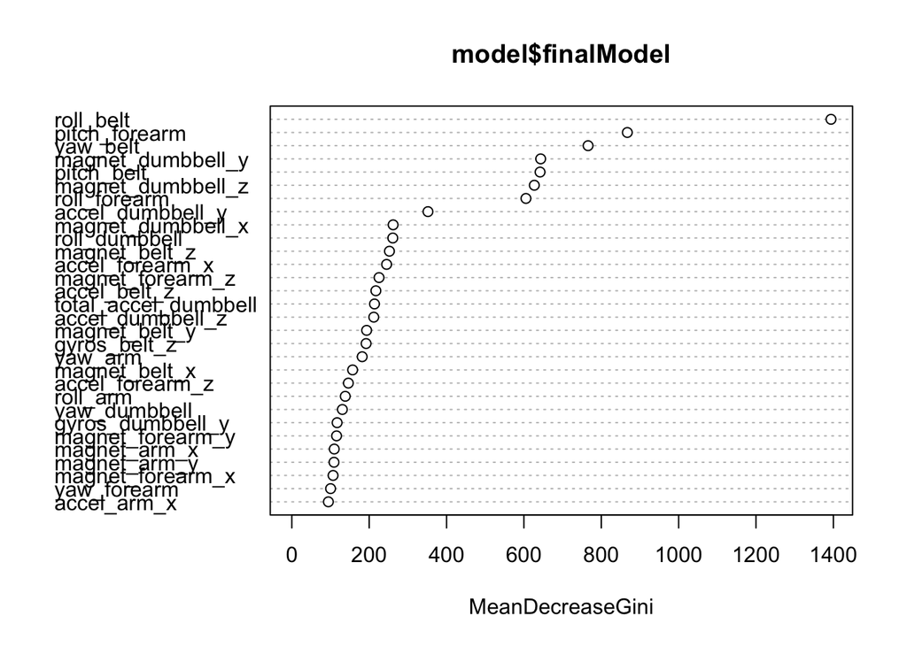